# MSDS595: Introduction to Time Series

Ruobin Gong, ruobin.gong@rutgers.edu

10/29/2020

Examples and code presented in this document are adapted from Cryer & Chan (2008) and its accompanying website: `http://homepage.divms.uiowa.edu/~kchan/TSA.htm`.

```r
library(TSA)
```

## Examples of stochastic processes.

### 1. White noise.

Simulate a white noise series with $t_9$ distribution.

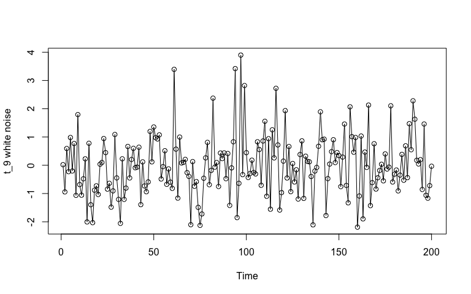

```r
n=200
set.seed(10)
sim.white.noise=ts(rt(n, df=9), freq=1, start=1)
plot(sim.white.noise,type='o',ylab='t_9 white noise')
```

### 2. Random walk.

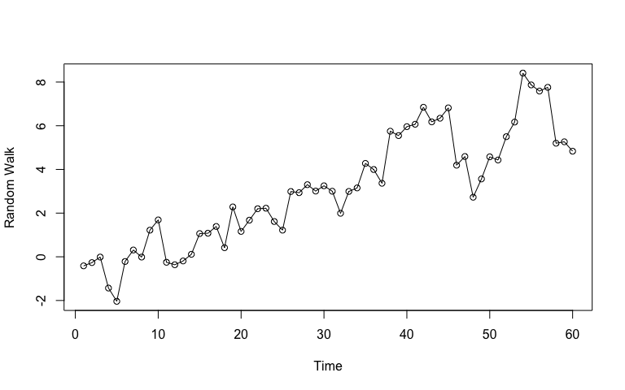

```r
# Exhibit 2.1
data(rwalk) # rwalk contains a simulated random walk
plot(rwalk,type='o',ylab='Random Walk')
```

R code for simulating several runs of random walk with, say 60, iid standard normal errors.

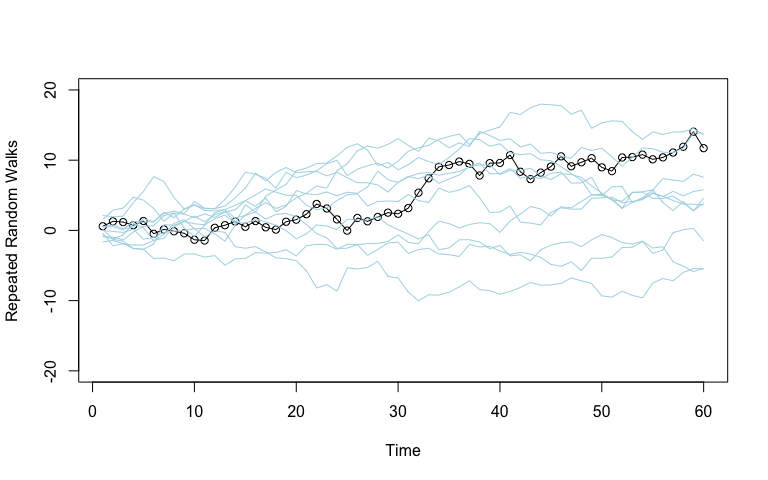

```r
n=60
set.seed(12345) # intialize the random number so that the simulation can be reproducible.
sim.random.walk=ts(cumsum(rnorm(n)),freq=1,start=1)
plot(sim.random.walk,type='o',ylab='Repeated Random Walks', ylim = c(-20, 20))
for (i in 1:10){
  points(ts(cumsum(rnorm(n)),freq=1,start=1), type = 'l', col = 'lightblue')
}
```

### 3. Moving average.

Use the simulated white noise from above, construct a two-point moving average series:

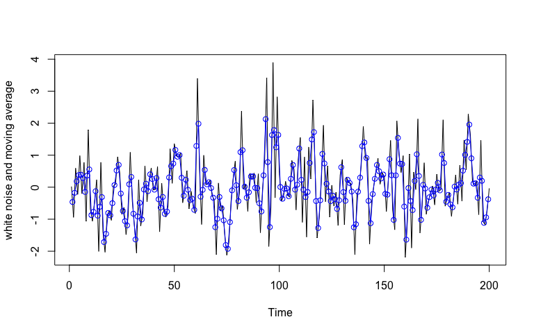

```r
n=200
sim.moving.average=(sim.white.noise[1:(n-1)] + sim.white.noise[2:n])/2
plot(sim.white.noise,type='l',ylab='white noise and moving average')
points((1:(n-1))+0.5, sim.moving.average,type = 'o', col = 'blue')
```

Let’s try a five-point moving average on the same series:

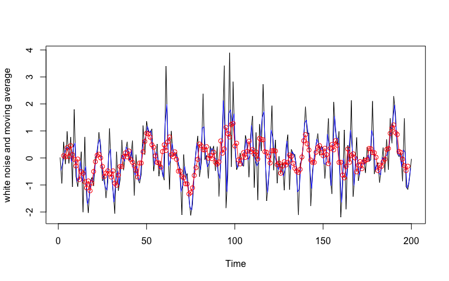

```r
sim.moving.average2=(sim.white.noise[1:(n-4)] +
                       sim.white.noise[2:(n-3)] +
                       sim.white.noise[3:(n-2)] +
                       sim.white.noise[4:(n-1)] +
                       sim.white.noise[5:n])/5
plot(sim.white.noise,type='l',ylab='white noise and moving average')
points((1:(n-1))+0.5, sim.moving.average,type = 'l', col = 'blue')
points(3:(n-2), sim.moving.average2,type = 'o', col = 'red')
```

**Note. White noise and moving average series are always stationary**.

### 4. Random cosine wave.

We simulate a cosine wave with frequency $1/12$ and a random phase, $\Phi \sim Unif[0, 1]$.

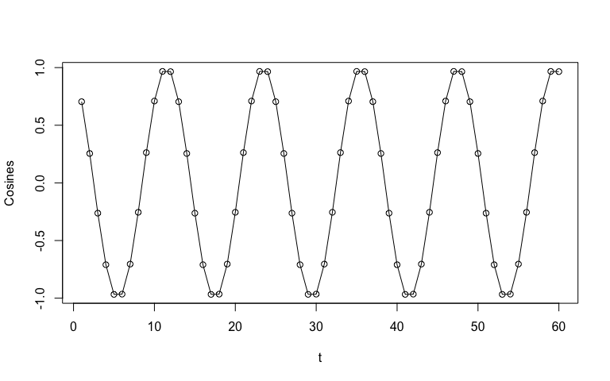

```r
t=1:60 # n=96
f=1/12 # frequency
set.seed(10)
sim.cos=cos(2*pi*f*(t+runif(1))) # cosine wave with random phase
plot(t, sim.cos, type='o', ylab='Cosines')
```

As we see the curve looks like it’s perfectly deterministic for one simulation. Let’s do this a few times to see the variability.

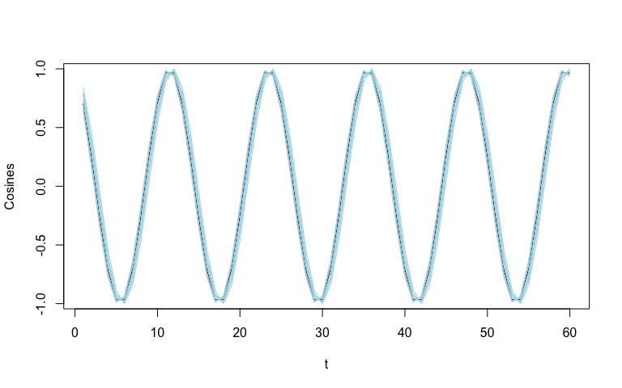

```r
plot(t, sim.cos, type='l', ylab='Cosines')
for (i in 1:10){
  sim.cos=cos(2*pi*f*(t+runif(1))) # cosine wave with random phase
  points(t, sim.cos, type='l', col = 'lightblue')
}
```

## Deterministic Trends in Time Series.

#### A time series with no trend nor seasonality.

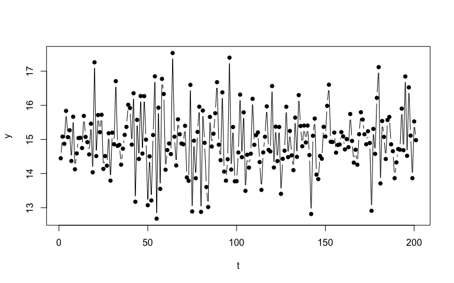

```r
set.seed(100)
t=c(1:201)
y = 14.95 + rnorm(201)
plot(t,y, type="b",pch=16)
```

#### A time series with an additive linear trend.

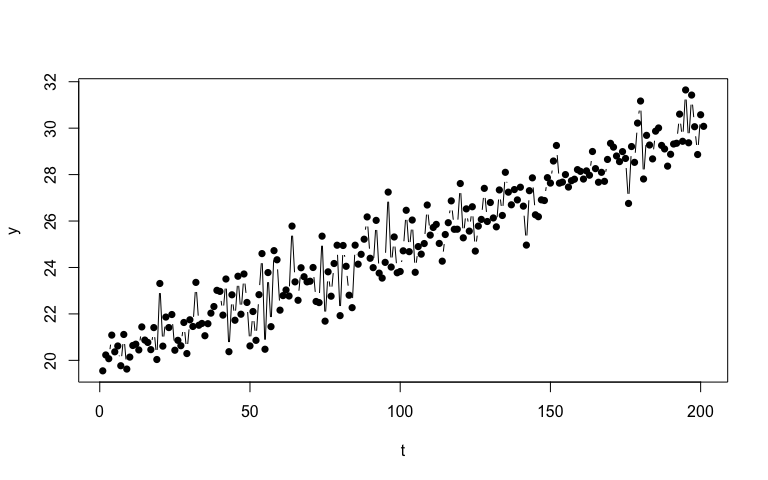

```r
set.seed(100)
t=c(1:201)
y = 20 + .05*t + rnorm(201)
plot(t,y, type="b",pch=16)
```

Fit a linear model to parse out the trend component:
$$Y_t = \beta_0 + \beta_1 t + X_t$$
Notice that the parameter values used for simulation is quite nicely recovered by the `lm` fit below.

```r
out1 = lm(y ~ t)
summary(out1)
```

```
##
## Call:
## lm(formula = y ~ t)
##
## Residuals:
##      Min       1Q   Median       3Q      Max
## -2.27585 -0.50234 -0.06698  0.50952  2.57741
##
## Coefficients:
##             Estimate Std. Error t value Pr(>|t|)
## (Intercept) 20.00008    0.12929  154.70   <2e-16 ***
## t            0.05007    0.00111   45.11   <2e-16 ***
## ---
## Signif. codes:  0 '***' 0.001 '**' 0.01 '*' 0.05 '.' 0.1 ' ' 1
##
## Residual standard error: 0.9131 on 199 degrees of freedom
## Multiple R-squared:  0.9109, Adjusted R-squared:  0.9105
## F-statistic:  2035 on 1 and 199 DF,  p-value: < 2.2e-16
```

Regression diagnostics: **residual analysis**. We will talk about what these are.

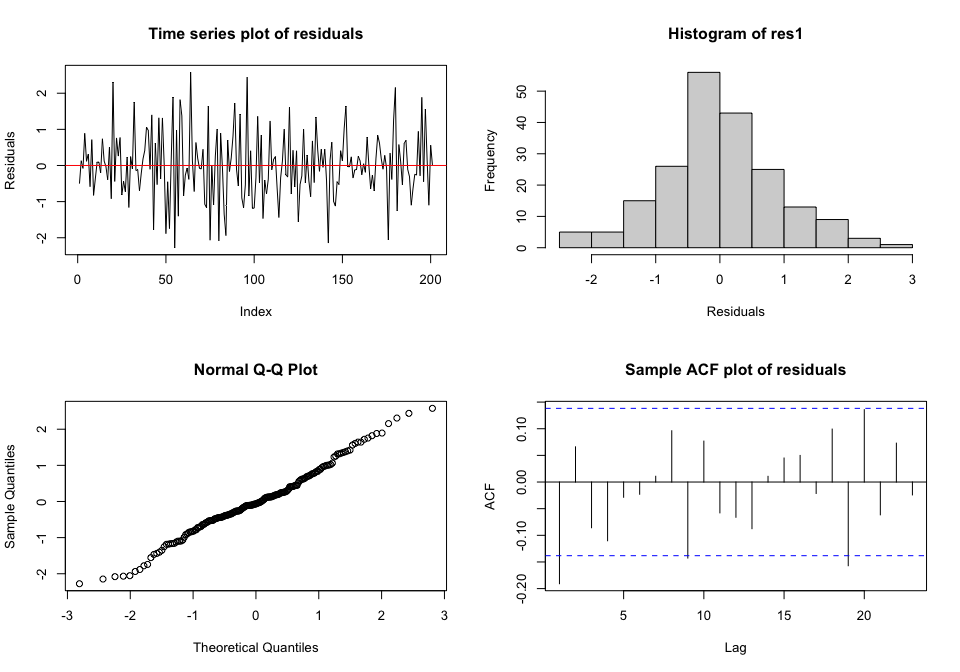

```r
res1 = residuals(out1)
par(mfrow=c(2,2))
plot(res1, type="l",main="Time series plot of residuals",ylab="Residuals")
abline(h=0, col="red")
hist(res1, xlab="Residuals")
qqnorm(res1)
acf(res1, main="Sample ACF plot of residuals")
```

#### Another time series with a trend [will revisit].

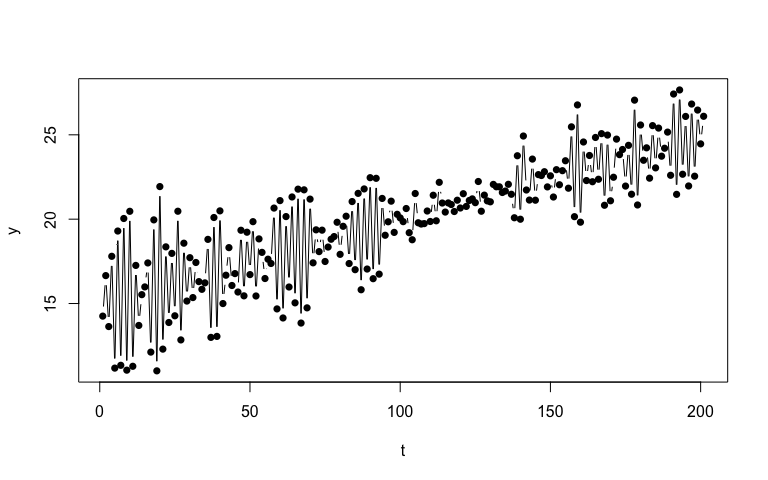

```r
set.seed(100)
t=c(1:201)
x = arima.sim(n = 201, list(ar=c(-0.85)))
y = 20 + .05*(t-101) + x
par(mfrow=c(1,1))
plot(t,y, type="b",pch=16)
```

#### A third time series with a trend [will revisit].

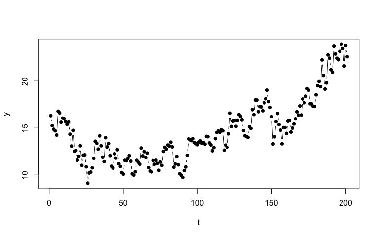

```r
set.seed(100)
t=c(1:201)
x = arima.sim(n = 201, list(ar=c(0.9)))
y = 14.95 - 0.08*t + 0.0006*(t^2)+x
par(mfrow=c(1,1))
plot(t,y, type="b",pch=16)
```

## Regression methods for removing Trend and Seasonality components.

### Linear and quadratic trends in time.

Consider a linear model to the random walk series $\{Y_t\}$ as follows:
$$Y_t = \beta_0 + \beta_1 t + X_t.$$

```r
# Exhibit 3.1
# time(rwalk) yields a time series of the time epoches when the random walk was sampled.
data(rwalk)
model1=lm(rwalk~time(rwalk))
summary(model1)
```

```
##
## Call:
## lm(formula = rwalk ~ time(rwalk))
##
## Residuals:
##      Min       1Q   Median       3Q      Max
## -2.70045 -0.79782  0.06391  0.63064  2.22128
##
## Coefficients:
##              Estimate Std. Error t value Pr(>|t|)
## (Intercept) -1.007888   0.297245  -3.391  0.00126 **
## time(rwalk)  0.134087   0.008475  15.822  < 2e-16 ***
## ---
## Signif. codes:  0 '***' 0.001 '**' 0.01 '*' 0.05 '.' 0.1 ' ' 1
##
## Residual standard error: 1.137 on 58 degrees of freedom
## Multiple R-squared:  0.8119, Adjusted R-squared:  0.8086
## F-statistic: 250.3 on 1 and 58 DF,  p-value: < 2.2e-16
```

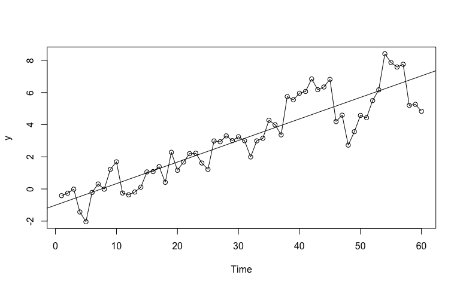

```r
# Exhibit 3.2
# rwalk contains a simulated random walk
plot(rwalk,type='o',ylab='y')
abline(model1) # add the fitted least squares line
```

### Cyclical and Seasonal trends.

The average monthly temperatures (in degrees Fahrenheit) over a number of years recorded in Dubuque, Iowa, are shown in Exhibit 1.7. This time series displays a very regular pattern called **seasonality**. Seasonality for monthly values occurs when observations twelve months apart are related in some manner or another. All Januarys and Februarys are quite cold but they are similar in value and different from the temperatures of the warmer months of June, July, and August, for example. There is still variation among the January values and variation among the June values.

Fit a seasonal means model, with one constant parameter per month, 12 total.

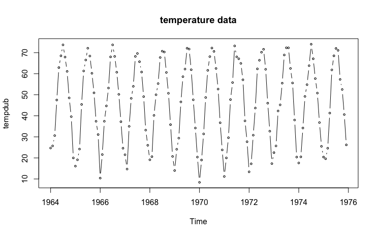

```r
# Exhibit 1.7
data(tempdub)
plot(tempdub,type = 'b',cex=0.5,main = 'temperature data')
```

**Note**: with all 12 $\beta$’s as well as the intercept, the linear model is no longer identifable so we must do something to make it identifiable, either by a) dropping the intercept term, or b) drop one of the $\beta$’s. This is what `model2` and `model3` below did respectively.

```r
# Exhibit 3.3
# season(tempdub) creates a vector of the month index of the data as a factor
month.=season(tempdub) # the period sign is included to make the printout from the commands two line below clearer; ditto below.
model2=lm(tempdub~month.-1) # -1 removes the intercept term
summary(model2)
```

```
##
## Call:
## lm(formula = tempdub ~ month. - 1)
##
## Residuals:
##     Min      1Q  Median      3Q     Max
## -8.2750 -2.2479  0.1125  1.8896  9.8250
##
## Coefficients:
##                 Estimate Std. Error t value Pr(>|t|)
## month.January     16.608      0.987   16.83   <2e-16 ***
## month.February    20.650      0.987   20.92   <2e-16 ***
## month.March       32.475      0.987   32.90   <2e-16 ***
## month.April       46.525      0.987   47.14   <2e-16 ***
## month.May         58.092      0.987   58.86   <2e-16 ***
## month.June        67.500      0.987   68.39   <2e-16 ***
## month.July        71.717      0.987   72.66   <2e-16 ***
## month.August      69.333      0.987   70.25   <2e-16 ***
## month.September   61.025      0.987   61.83   <2e-16 ***
## month.October     50.975      0.987   51.65   <2e-16 ***
## month.November    36.650      0.987   37.13   <2e-16 ***
## month.December    23.642      0.987   23.95   <2e-16 ***
## ---
## Signif. codes:  0 '***' 0.001 '**' 0.01 '*' 0.05 '.' 0.1 ' ' 1
##
## Residual standard error: 3.419 on 132 degrees of freedom
## Multiple R-squared:  0.9957, Adjusted R-squared:  0.9953
## F-statistic:  2569 on 12 and 132 DF,  p-value: < 2.2e-16
```

```r
# Exhibit 3.4
model3=lm(tempdub~month.) # intercept is automatically included so one month (Jan) is dropped
summary(model3)
```

```
##
## Call:
## lm(formula = tempdub ~ month.)
##
## Residuals:
##     Min      1Q  Median      3Q     Max
## -8.2750 -2.2479  0.1125  1.8896  9.8250
##
## Coefficients:
##                 Estimate Std. Error t value Pr(>|t|)
## (Intercept)       16.608      0.987  16.828  < 2e-16 ***
## month.February     4.042      1.396   2.896  0.00443 **
## month.March       15.867      1.396  11.368  < 2e-16 ***
## month.April       29.917      1.396  21.434  < 2e-16 ***
## month.May         41.483      1.396  29.721  < 2e-16 ***
## month.June        50.892      1.396  36.461  < 2e-16 ***
## month.July        55.108      1.396  39.482  < 2e-16 ***
## month.August      52.725      1.396  37.775  < 2e-16 ***
## month.September   44.417      1.396  31.822  < 2e-16 ***
## month.October     34.367      1.396  24.622  < 2e-16 ***
## month.November    20.042      1.396  14.359  < 2e-16 ***
## month.December     7.033      1.396   5.039 1.51e-06 ***
## ---
## Signif. codes:  0 '***' 0.001 '**' 0.01 '*' 0.05 '.' 0.1 ' ' 1
##
## Residual standard error: 3.419 on 132 degrees of freedom
## Multiple R-squared:  0.9712, Adjusted R-squared:  0.9688
## F-statistic: 405.1 on 11 and 132 DF,  p-value: < 2.2e-16
```

With the intercept in, R’s default is to drop the first $\beta$, corresponding to January. Pay attention to the difference in the interpretation of the estimated parameter values. That being said, either model should give exactly the same fitted values.

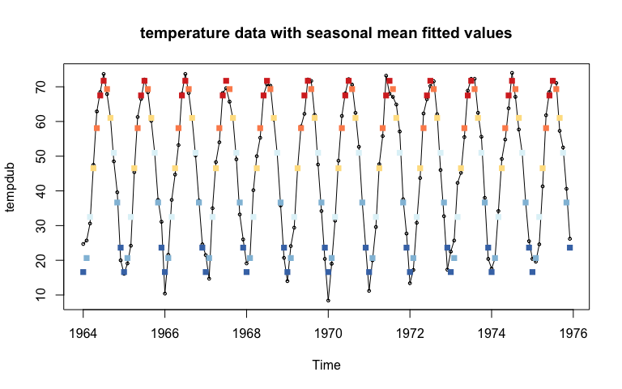

```r
library(RColorBrewer) # This is a nice package to give  you great plotting colors. You will need to install it before using for the first time.
temp.color = c(rev(brewer.pal(6, 'RdYlBu')), brewer.pal(6, 'RdYlBu')) # creating a color vector for the 12 months
plot(tempdub, main='temperature data with seasonal mean fitted values')
points(tempdub, cex = 0.5)
points(ts(fitted.values(model2),start=1964,frequency=12), col=temp.color, pch = 15)
```

### Cosine trends.

We look at the same temperature data.

```r
# Exhibit 3.5
# first creates the first pair of harmonic functions and then fit the model
har.=harmonic(tempdub,1)
model4=lm(tempdub~har.)
summary(model4)
```

```
##
## Call:
## lm(formula = tempdub ~ har.)
##
## Residuals:
##      Min       1Q   Median       3Q      Max
## -11.1580  -2.2756  -0.1457   2.3754  11.2671
##
## Coefficients:
##                 Estimate Std. Error t value Pr(>|t|)
## (Intercept)      46.2660     0.3088 149.816  < 2e-16 ***
## har.cos(2*pi*t) -26.7079     0.4367 -61.154  < 2e-16 ***
## har.sin(2*pi*t)  -2.1697     0.4367  -4.968 1.93e-06 ***
## ---
## Signif. codes:  0 '***' 0.001 '**' 0.01 '*' 0.05 '.' 0.1 ' ' 1
##
## Residual standard error: 3.706 on 141 degrees of freedom
## Multiple R-squared:  0.9639, Adjusted R-squared:  0.9634
## F-statistic:  1882 on 2 and 141 DF,  p-value: < 2.2e-16
```

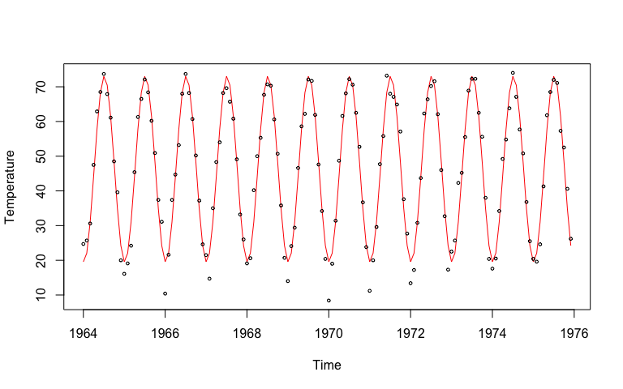

```r
# A modified Exhibit 3.6
plot(ts(fitted(model4),freq=12,start=c(1964,1)),ylab='Temperature',type='l',ylim=range(c(fitted(model4),tempdub)), col = 'red') # the ylim option ensures that the
# y axis has a range that fits the raw data and the fitted values
points(tempdub, cex = 0.5)
```

## Residual analysis.

**Temperature data revisited**. Exhibits 8-9: If the stochastic component is white noise and the trend is adequately modeled, we would expect such a plot to suggest a rectangular scatter with no discernible trends whatsoever. There are no striking departures from randomness apparent in this display.

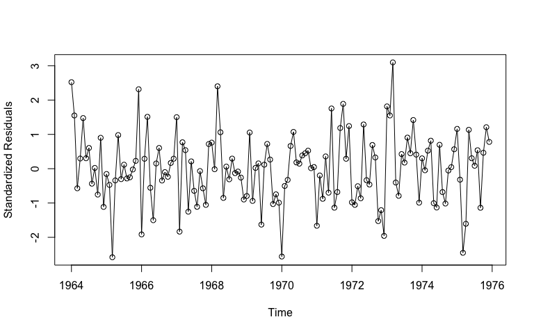

```r
# Exhibit 3.8
plot(y=rstudent(model3),x=as.vector(time(tempdub)),xlab='Time',ylab='Standardized Residuals',type='o')
```

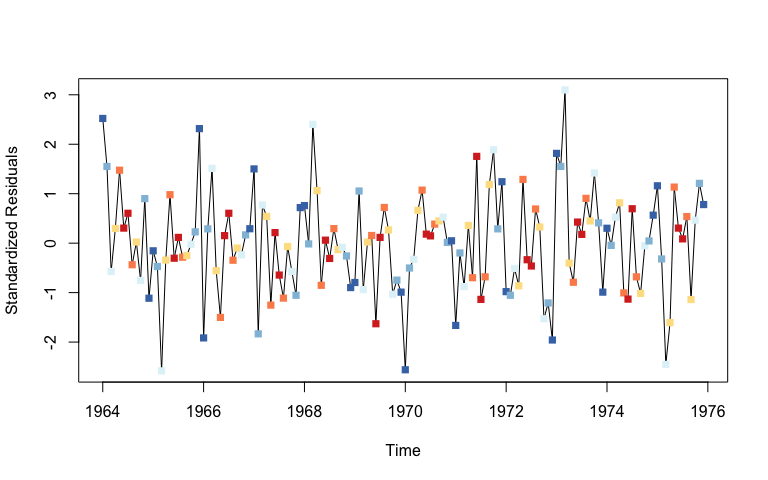

```r
# a modified Exhibit 3.9
plot(y=rstudent(model3),x=as.vector(time(tempdub)),xlab='Time',
ylab='Standardized Residuals',type='l')
#points(y=rstudent(model3),x=as.vector(time(tempdub)), pch=as.vector(season(tempdub)))
points(y=rstudent(model3),x=as.vector(time(tempdub)), col=temp.color, pch = 15)
```

Exhibit 10 uses standardized residuals. Patterns? Are small residuals associated with small fitted trend values and large residuals with large fitted trend values? There is somewhat more variation for the March residuals and less for November, but does not indicate any dramatic patterns that would cause us to doubt the seasonal means model.

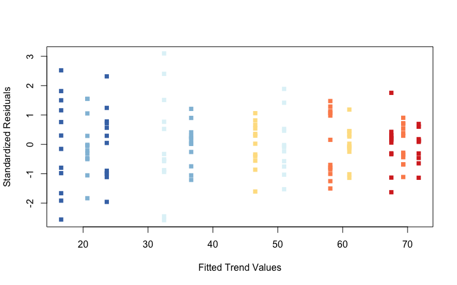

```r
# Exhibit 3.10
plot(y=rstudent(model3),x=as.vector(fitted(model3)),xlab='Fitted Trend Values',
ylab='Standardized Residuals',type="n")
#points(y=rstudent(model3),x=as.vector(fitted(model3)), pch=as.vector(season(tempdub)))
points(y=rstudent(model3),x=as.vector(fitted(model3)),
col = temp.color, pch = 15)
```

Gross nonnormality can be assessed by plotting a histogram of the residuals or standardized residuals.

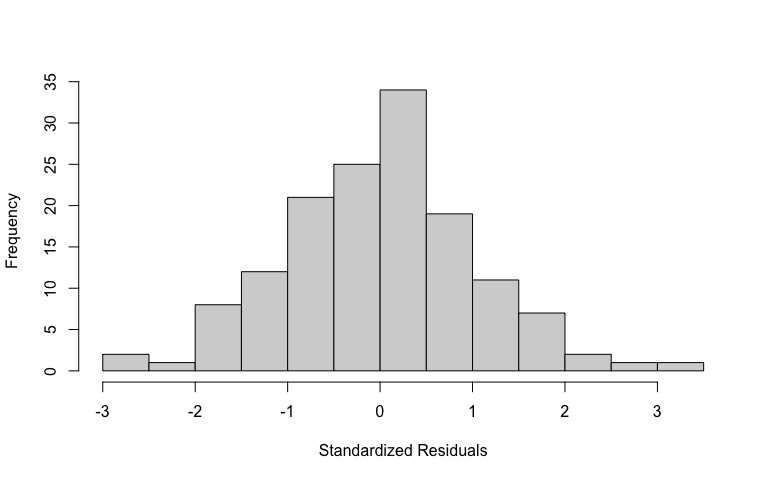

```r
# Exhibit 3.11
hist(rstudent(model3),xlab='Standardized Residuals',main='')
```

…and with QQ plot: displays the quantiles of the data versus the theoretical quantiles of a normal distribution. With normally distributed data, the QQ plot looks approximately like a straight line.

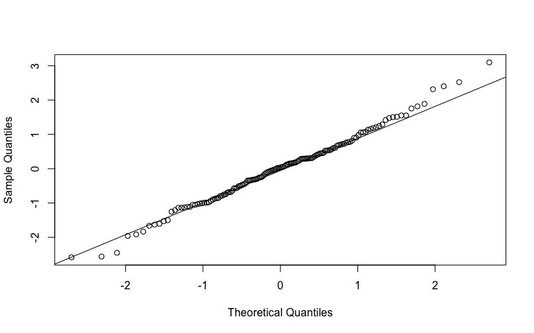

```r
# Exhibit 3.12
qqnorm(rstudent(model3),main=''); qqline(rstudent(model3))
```

### Shapiro-Wilk test.

S-W is a test of **normality**. It calculates the correlation between the residuals and the corresponding normal quantiles. The lower this correlation, the more evidence we have against normality.

```r
shapiro.test(rstudent(model3))
```

```
##
##  Shapiro-Wilk normality test
##
## data:  rstudent(model3)
## W = 0.9929, p-value = 0.6954
```

Note the interpretation of the S-W test. A **large** p-value (e.g. >0.05) means we **cannot** reject the null hypothesis that the stochastic component of this model is normally distributed. On the other hand a **small** p-value rejects the null and **provides evidence against the normality assumption**.

### The runs test.

Runs test is a test of **independence**. In the residual sequence, runs above or below their median are counted. Too many or two few runs will indeicate neighboring residuals are negatively and positive correlated, respectively, so either too few or too many runs lead us to reject independence.

```r
runs(rstudent(model3))
```

```
## $pvalue
## [1] 0.216
##
## $observed.runs
## [1] 65
##
## $expected.runs
## [1] 72.875
##
## $n1
## [1] 69
##
## $n2
## [1] 75
##
## $k
## [1] 0
```

A large p-value means we cannot reject the assumption of residual independence.

### Sample Autocorrelation Function (ACF).

The sample ACF of lag $k$ is given by
$$\hat{\rho}_k = r_k = \frac{ \sum_{t=k+1}^n(y_t - \bar{y})(y_{t-k} - \bar{y})}{\sum_{t=1}^n (y_t - \bar{y})^2}$$
where $\bar{y} = \frac{1}{n} \sum_{t=1}^n y_t$.

#### Example 1: seasonal means model of the temperature

Exhibit 3.13 displays the sample autocorrelation for the standardized residuals from the seasonal means model of the temperature series.For k = 1, 2,…, 21, none of the hypotheses $\rho_k = 0$ can be rejected at the usual significance levels, and it is reasonable to infer that the stochastic component of the series is white noise.

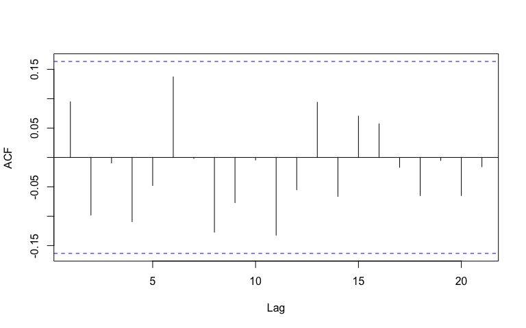

```r
# Exhibit 3.13
acf(rstudent(model3),main='')
```

#### Example 2: fitting a straight line to random walk.

Standardized residuals from fitting a straight line to the random walk time series. residuals *hang together* too much for white noise, i.e. the plot is too smooth. `runs` test confirms this too.

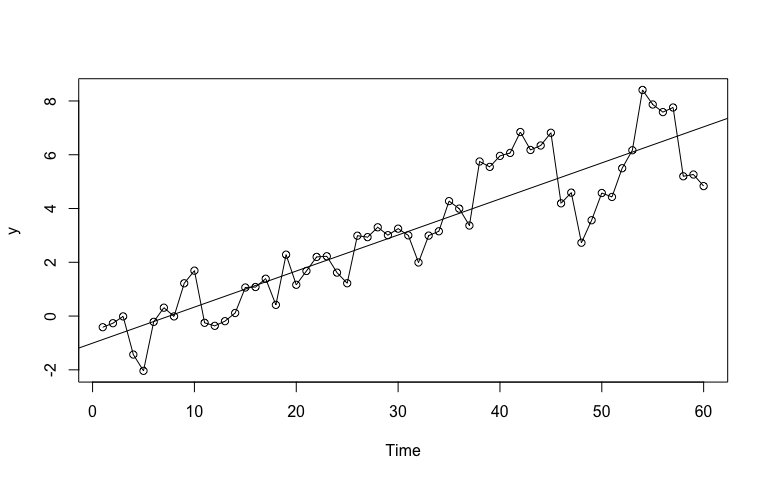

```r
# Exhibit 3.2
plot(rwalk,type='o',ylab='y')
abline(model1)
```

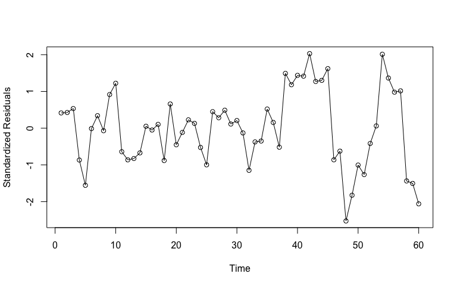

```r
# Exhibit 3.14
plot(y=rstudent(model1),x=as.vector(time(rwalk)),ylab='Standardized Residuals',
xlab='Time',type='o')
```

```r
runs(rstudent(model1))
```

```
## $pvalue
## [1] 0.0266
##
## $observed.runs
## [1] 22
##
## $expected.runs
## [1] 30.96667
##
## $n1
## [1] 29
##
## $n2
## [1] 31
##
## $k
## [1] 0
```

Also, larger residuals associated with larger fitted values.

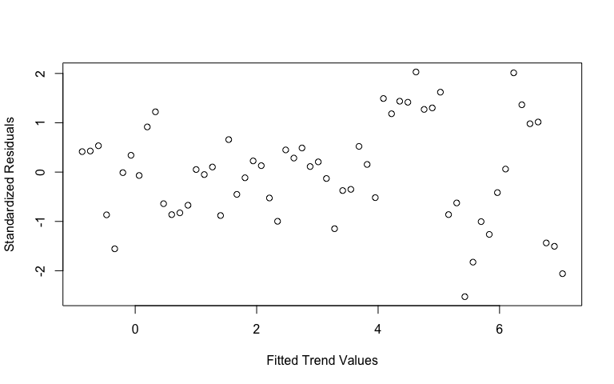

```r
# Exhibit 3.15
plot(y=rstudent(model1),x=fitted(model1),ylab='Standardized Residuals',
xlab='Fitted Trend Values',type='p')
```

Sample ACF confirms visualized smoothness: lag 1 and lag 2 autocorrelations exceed two standard errors above zero, lag 5 and lag 6 autocorrelations more than two standard errors below zero.

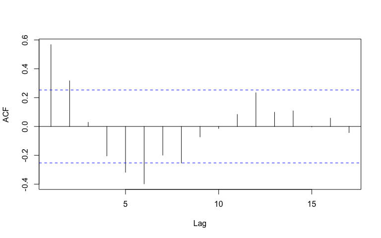

```r
# Exhibit 3.16
acf(rstudent(model1),main='')
```

#### Another time series with a trend [revisited].

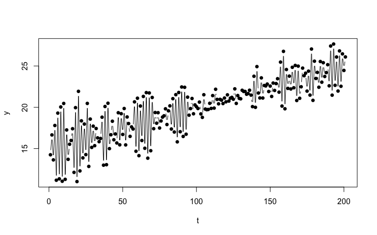

```r
set.seed(100)
t=c(1:201)
x = arima.sim(n = 201, list(ar=c(-0.85)))
y = 20 + .05*(t-101) + x
par(mfrow=c(1,1))
plot(t,y, type="b",pch=16)
```

```r
out1 = lm(y ~ t)
summary(out1)
```

```
##
## Call:
## lm(formula = y ~ t)
##
## Residuals:
##     Min      1Q  Median      3Q     Max
## -4.8692 -1.1366 -0.0103  1.3429  6.0032
##
## Coefficients:
##              Estimate Std. Error t value Pr(>|t|)
## (Intercept) 14.928827   0.290353   51.42   <2e-16 ***
## t            0.049992   0.002493   20.05   <2e-16 ***
## ---
## Signif. codes:  0 '***' 0.001 '**' 0.01 '*' 0.05 '.' 0.1 ' ' 1
##
## Residual standard error: 2.051 on 199 degrees of freedom
## Multiple R-squared:  0.669,  Adjusted R-squared:  0.6673
## F-statistic: 402.2 on 1 and 199 DF,  p-value: < 2.2e-16
```

```r
res1 = residuals(out1)
```

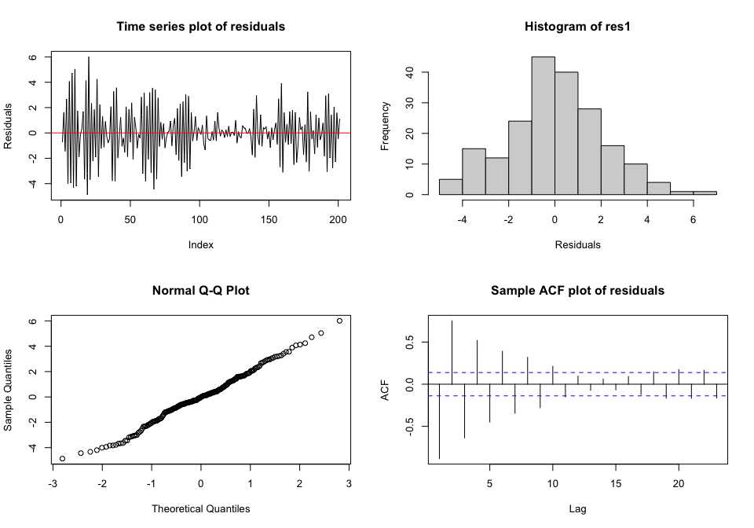

```r
par(mfrow=c(2,2))
plot(res1, type="l",main="Time series plot of residuals",ylab="Residuals")
abline(h=0, col="red")
hist(res1, xlab="Residuals")
qqnorm(res1)
acf(res1, main="Sample ACF plot of residuals")
```

#### A third time series with a trend [revisited].

This is a time series simulated with a quadratic trend and a stochastic component (that is an *Autoregressive(0.9)* process).

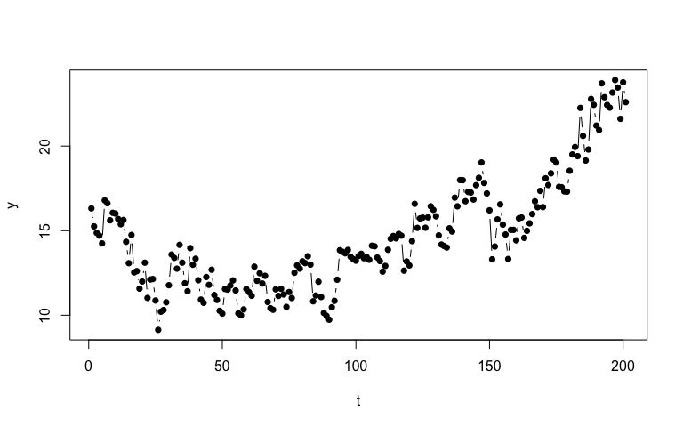

```r
set.seed(100)
t=c(1:201)
x = arima.sim(n = 201, list(ar=c(0.9)))
y = 14.95 - 0.08*t + 0.0006*(t^2)+x
par(mfrow=c(1,1))
plot(t,y, type="b",pch=16)
```

To fit a quadratic trend to the model, create `tsq` which is the basis that is quadratic in time. The linear model is
$$Y_t = \beta_0 + \beta_1 t + \beta_2 t^2 + X_t$$

```r
tsq = t^2
out1 = lm(y ~  t + tsq)
summary(out1)
```

```
##
## Call:
## lm(formula = y ~ t + tsq)
##
## Residuals:
##    Min     1Q Median     3Q    Max
## -3.761 -1.011  0.038  1.184  3.226
##
## Coefficients:
##               Estimate Std. Error t value Pr(>|t|)
## (Intercept)  1.457e+01  3.121e-01   46.68   <2e-16 ***
## t           -8.013e-02  7.135e-03  -11.23   <2e-16 ***
## tsq          6.022e-04  3.421e-05   17.60   <2e-16 ***
## ---
## Signif. codes:  0 '***' 0.001 '**' 0.01 '*' 0.05 '.' 0.1 ' ' 1
##
## Residual standard error: 1.46 on 198 degrees of freedom
## Multiple R-squared:  0.8123, Adjusted R-squared:  0.8104
## F-statistic: 428.4 on 2 and 198 DF,  p-value: < 2.2e-16
```

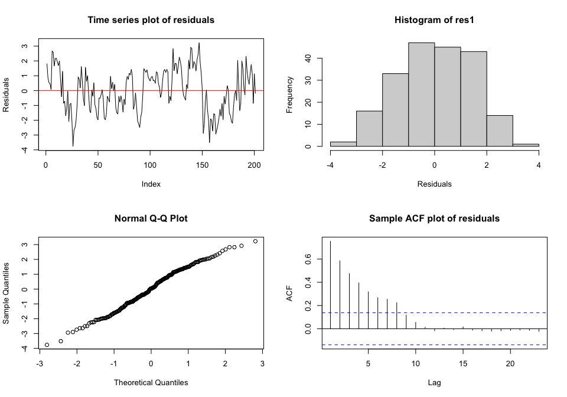

```r
par(mfrow=c(2,2))
res1 = residuals(out1)
plot(res1, type="l",main="Time series plot of residuals",ylab="Residuals")
abline(h=0, col="red")
hist(res1, xlab="Residuals")
qqnorm(res1)
acf(res1, main="Sample ACF plot of residuals")
```